# Section 1: Basics of Machine Learning

2026-06-02

# 1 The Idea of Machine Learning

**Machine learning** is concerned with building algorithms that estimate a function $\hat{f}$ from data, rather than having a human expert specify its parameters directly. The contrast is with *rule-based* systems, where a programmer encodes decisions by hand (e.g. “if temperature $> 38^\circ$C, flag as fever”). In ML the parameters — whether the slope of a line, the splits of a decision tree, or the weights of a neural network — are determined automatically by minimising a loss function over the training data. A human expert designs the model *class* and the learning algorithm; the data determine the specific values.

In general, we observe $n$ data points, each consisting of $p$ measured features (predictors) $X = (X_1, X_2, \ldots, X_p)$. What the algorithm does with those features depends on the type of problem:

- In **supervised learning** there is also a response $Y$ for each observation, and the goal is to learn the mapping $X \to Y$.
- In **unsupervised learning** there is no $Y$; the goal is to discover structure (clusters, dimensions) in $X$ alone.

These two settings are discussed in detail in Section 3. The rest of this section introduces terminology common to both.

**Why fit a model to data?** Two main reasons: *prediction* and *inference* (see Section 2).

**Key terminology:**

- **Training data**: the observations used to fit (learn) the model.
- **Test data**: new observations used to evaluate how well the model generalises.
- **Model / learner**: the estimated function $\hat{f}$.

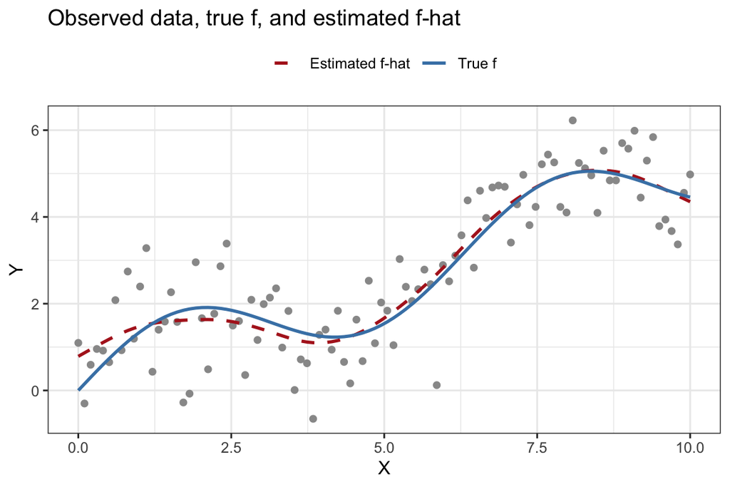

Figure 1.1: A supervised learning example: noisy observations of one predictor and a response, with the true f (blue) and an estimated f-hat (red).

```r
set.seed(42)
x <- seq(0, 10, length.out = 100)
f_true <- sin(x) + 0.5 * x
y <- f_true + rnorm(100, sd = 0.8)

fit     <- smooth.spline(x, y, df = 7)
y_hat   <- predict(fit, x)$y

df_pts  <- data.frame(x = x, y = y)
df_line <- data.frame(
  x     = rep(x, 2),
  value = c(f_true, y_hat),
  curve = rep(c("True f", "Estimated f-hat"), each = length(x))
)

ggplot() +
  geom_point(data = df_pts, aes(x = x, y = y), colour = "grey60", size = 1.5) +
  geom_line(data = df_line, aes(x = x, y = value, colour = curve, linetype = curve),
            linewidth = 0.9) +
  scale_colour_manual(values = c("True f" = "steelblue",
                                 "Estimated f-hat" = "firebrick")) +
  scale_linetype_manual(values = c("True f" = "solid",
                                   "Estimated f-hat" = "dashed")) +
  labs(title = "Observed data, true f, and estimated f-hat",
       x = "X", y = "Y", colour = NULL, linetype = NULL) +
  theme_bw() +
  theme(legend.position = "top")
```

Figure 1.1 shows a simple supervised example: noisy observations around an unknown $f$, and the estimate $\hat{f}$ recovered from the data alone.

# 2 Inference vs. Prediction

Although the same model $\hat{f}$ underlies both goals, what we *do* with it differs.

|  | **Inference** | **Prediction** |
| --- | --- | --- |
| **Question** | How does $Y$ change with $X_j$? | What is $\hat{Y}$ for a new $X$? |
| **Focus** | Interpretability, significance | Accuracy of $\hat{Y}$ |
| **$\hat{f}$ needs to be…** | Interpretable | Accurate (black-box OK) |
| **Example** | Does advertising on TV increase sales? | What will sales be next quarter? |

> This course focuses on **prediction**. You have seen inference in your previous statistics courses (hypothesis testing, confidence intervals, linear model interpretation).

For prediction, the **expected prediction error** for a new observation $x_0$ decomposes as:

$$\mathbb{E}\left[(Y - \hat{f}(x_0))^2\right] = \underbrace{\text{Var}(\varepsilon)}_{\text{irreducible}} + \underbrace{\left[\text{Bias}(\hat{f}(x_0))\right]^2 + \text{Var}(\hat{f}(x_0))}_{\text{reducible}}$$

We can reduce the *reducible* error by choosing a better model; the *irreducible* error $\text{Var}(\varepsilon)$ sets a floor we cannot beat. This decomposition is explored further in Section 4.

```r
# Inference example: interpret coefficients
data(mtcars)
lm_fit <- lm(mpg ~ wt + hp, data = mtcars)
summary(lm_fit)$coefficients
```

```
##                Estimate Std. Error   t value     Pr(>|t|)
## (Intercept) 37.22727012 1.59878754 23.284689 2.565459e-20
## wt          -3.87783074 0.63273349 -6.128695 1.119647e-06
## hp          -0.03177295 0.00902971 -3.518712 1.451229e-03
```

```r
# Prediction example: predict for a new car
new_car <- data.frame(wt = 3.0, hp = 120)
predict(lm_fit, newdata = new_car, interval = "prediction")
```

```
##        fit      lwr      upr
## 1 21.78102 16.38174 27.18031
```

In the inference framing we care about the coefficient on `wt` and its p-value. In the prediction framing we care about the predicted `mpg` and its interval.

# 3 Supervised vs. Unsupervised Learning

## 3.1 Supervised Learning

We have labelled training data: each observation has both predictors $X$ **and** a response $Y$. The standard setup assumes

$$Y = f(X) + \varepsilon$$

where $f$ is an unknown function capturing the systematic relationship between $X$ and $Y$, and $\varepsilon$ is irreducible noise with $\mathbb{E}[\varepsilon] = 0$, independent of $X$. The goal is to estimate $f$ from training data $\{(x_i, y_i)\}_{i=1}^n$.

Depending on the nature of $Y$:

- **Regression**: $Y$ is quantitative (e.g., house price, temperature).
- **Classification**: $Y$ is categorical (e.g., spam / not-spam, disease / healthy).

The model is “supervised” because the true $Y$ values guide (supervise) the learning.

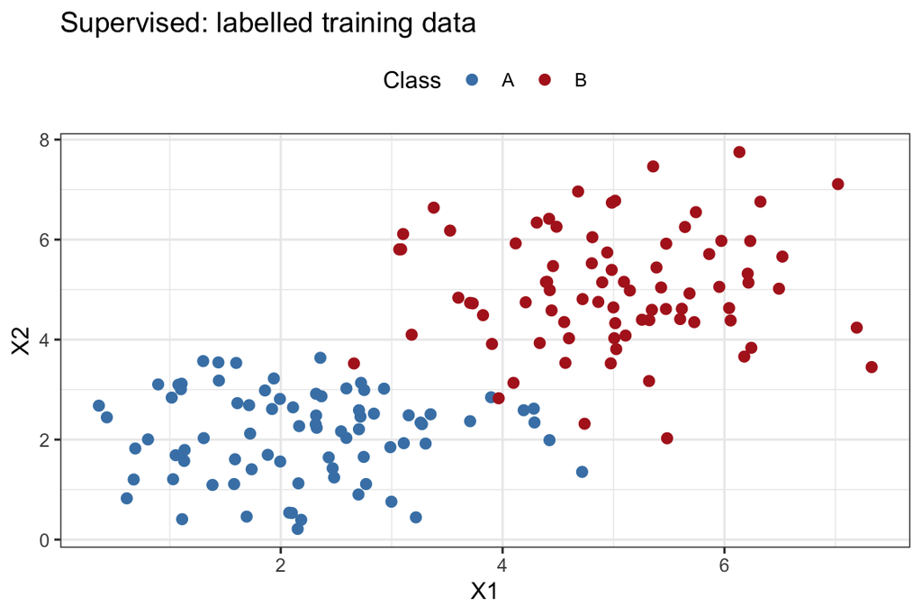

```r
set.seed(7)
n <- 80
dat <- rbind(
  data.frame(x1 = rnorm(n, 2, 1), x2 = rnorm(n, 2, 1), label = "A"),
  data.frame(x1 = rnorm(n, 5, 1), x2 = rnorm(n, 5, 1), label = "B")
)

ggplot(dat, aes(x = x1, y = x2, colour = label)) +
  geom_point(size = 2) +
  scale_colour_manual(values = c("A" = "steelblue", "B" = "firebrick")) +
  labs(title = "Supervised: labelled training data",
       x = "X1", y = "X2", colour = "Class") +
  theme_bw() +
  theme(legend.position = "top")
```

Figure 3.1 illustrates a binary classification problem where each point carries a known label — the defining feature of supervised learning.

## 3.2 Unsupervised Learning

We have **no response** $Y$ — only predictors $X$. The goal is to discover structure (clusters, dimensions) in the data.

Common methods: **K-means clustering**, **hierarchical clustering**, **principal component analysis (PCA)**.

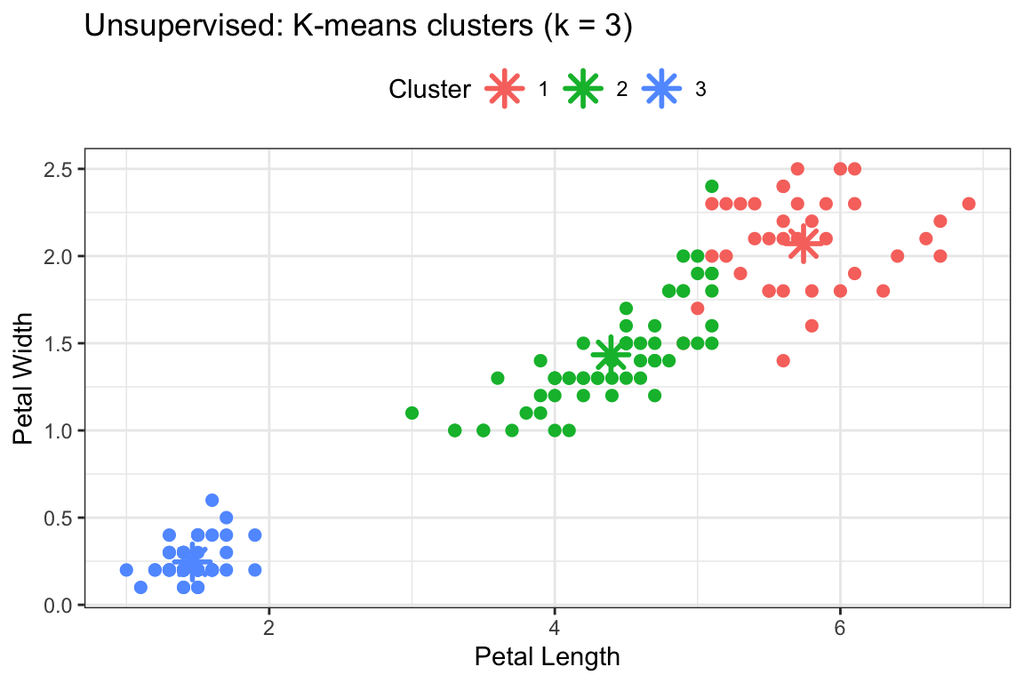

Figure 3.2: K-means clustering on the iris dataset (no labels used during fitting).

```r
data(iris)
set.seed(42)
km <- kmeans(iris[, 1:4], centers = 3, nstart = 20)

df_iris    <- data.frame(iris, cluster = factor(km$cluster))
df_centers <- data.frame(
  Petal.Length = km$centers[, 3],
  Petal.Width  = km$centers[, 4],
  cluster      = factor(1:3)
)

ggplot(df_iris, aes(x = Petal.Length, y = Petal.Width, colour = cluster)) +
  geom_point(size = 2) +
  geom_point(data = df_centers, shape = 8, size = 4, stroke = 1.5) +
  labs(title = "Unsupervised: K-means clusters (k = 3)",
       x = "Petal Length", y = "Petal Width", colour = "Cluster") +
  theme_bw() +
  theme(legend.position = "top")
```

Figure 3.2 shows K-means applied to `iris` using only the four measurements — species labels were not used.

> **Note**: In unsupervised learning we cannot evaluate performance against a known truth — there is no $Y$ to compare to. This makes evaluation harder than in the supervised setting (Section 5).

# 4 The Bias–Variance Trade-off

This is one of the central ideas in machine learning.

## 4.1 Decomposition

For a given $x_0$, the **mean squared error** of $\hat{f}(x_0)$ decomposes as:

$$\text{MSE}(x_0) = \text{Bias}^2(\hat{f}(x_0)) + \text{Var}(\hat{f}(x_0)) + \text{Var}(\varepsilon)$$

- **Bias**: error from wrong assumptions in the model. A very simple model (e.g. straight line through curved data) has high bias — it systematically misses the truth.
- **Variance**: sensitivity to fluctuations in the training set. A very complex model (e.g. interpolating every data point) has high variance — it changes a lot across different training samples.
- **Irreducible error**: noise in $Y$ itself; cannot be reduced (see Section 2).

The trade-off: **decreasing bias tends to increase variance, and vice versa**. The optimal model balances the two.

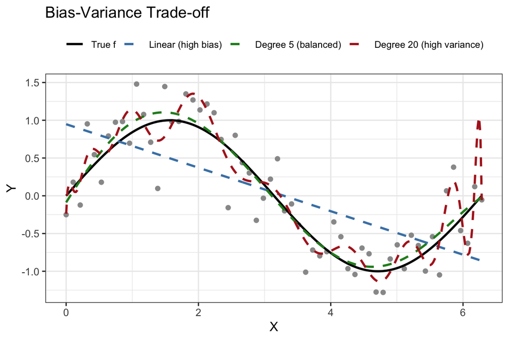

Figure 4.1: Three fits of increasing flexibility: linear (high bias), degree-5 polynomial (balanced), and degree-20 polynomial (high variance).

```r
set.seed(1)
x <- seq(0, 2 * pi, length.out = 60)
y <- sin(x) + rnorm(60, sd = 0.4)

fit_lin  <- lm(y ~ x)
fit_med  <- lm(y ~ poly(x, 5))
fit_over <- lm(y ~ poly(x, 20))

x_seq <- seq(0, 2 * pi, length.out = 300)
df_lines <- data.frame(
  x     = rep(x_seq, 4),
  value = c(sin(x_seq),
            predict(fit_lin,  newdata = data.frame(x = x_seq)),
            predict(fit_med,  newdata = data.frame(x = x_seq)),
            predict(fit_over, newdata = data.frame(x = x_seq))),
  model = rep(c("True f", "Linear (high bias)",
                "Degree 5 (balanced)", "Degree 20 (high variance)"),
              each = length(x_seq))
)
df_lines$model <- factor(df_lines$model,
                         levels = c("True f", "Linear (high bias)",
                                    "Degree 5 (balanced)", "Degree 20 (high variance)"))

ggplot() +
  geom_point(data = data.frame(x = x, y = y),
             aes(x = x, y = y), colour = "grey60", size = 1.5) +
  geom_line(data = df_lines, aes(x = x, y = value, colour = model, linetype = model),
            linewidth = 0.9) +
  scale_colour_manual(values = c("True f"                 = "black",
                                 "Linear (high bias)"     = "steelblue",
                                 "Degree 5 (balanced)"    = "forestgreen",
                                 "Degree 20 (high variance)" = "firebrick")) +
  scale_linetype_manual(values = c("True f"                 = "solid",
                                   "Linear (high bias)"     = "dashed",
                                   "Degree 5 (balanced)"    = "dashed",
                                   "Degree 20 (high variance)" = "dashed")) +
  labs(title = "Bias-Variance Trade-off",
       x = "X", y = "Y", colour = NULL, linetype = NULL) +
  theme_bw() +
  theme(legend.position = "top",
        legend.text = element_text(size = 8))
```

## 4.2 Model Complexity and the U-Curve

- Training error **always decreases**.
- Test error follows a **U-shape**: first decreases (bias falls faster than variance rises), then increases (variance dominates).

The minimum of the test error curve is the sweet spot.

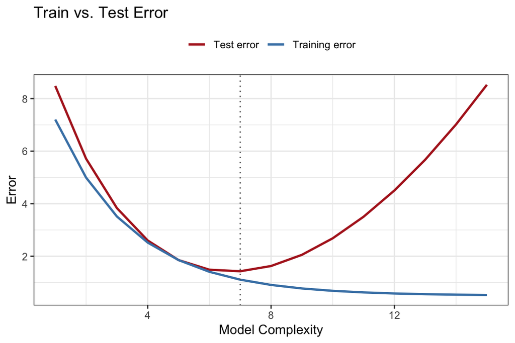

```r
complexity <- 1:15
df_curve <- data.frame(
  complexity = rep(complexity, 2),
  error      = c(10 * exp(-0.4 * complexity) + 0.5,
                 10 * exp(-0.4 * complexity) + 0.5 + 0.08 * (complexity - 5)^2),
  type       = rep(c("Training error", "Test error"), each = length(complexity))
)
opt <- complexity[which.min(10 * exp(-0.4 * complexity) + 0.5 + 0.08 * (complexity - 5)^2)]

ggplot(df_curve, aes(x = complexity, y = error, colour = type)) +
  geom_line(linewidth = 0.9) +
  geom_vline(xintercept = opt, linetype = "dotted", colour = "grey40") +
  scale_colour_manual(values = c("Training error" = "steelblue",
                                 "Test error"     = "firebrick")) +
  labs(title = "Train vs. Test Error",
       x = "Model Complexity", y = "Error", colour = NULL) +
  theme_bw() +
  theme(legend.position = "top")
```

# 5 Evaluation Metrics

How do we measure how well $\hat{f}$ performs on **test** data?

## 5.1 Regression Metrics

Let $y_i$ be the true value and $\hat{y}_i$ the predicted value for observation $i$.

**Mean Squared Error (MSE)**:
$$\text{MSE} = \frac{1}{n}\sum_{i=1}^n (y_i - \hat{y}_i)^2$$

**Root Mean Squared Error (RMSE)**: $\sqrt{\text{MSE}}$ — same units as $Y$, easier to interpret.

**Mean Absolute Error (MAE)**:
$$\text{MAE} = \frac{1}{n}\sum_{i=1}^n |y_i - \hat{y}_i|$$

**$R^2$ (coefficient of determination)**:
$$R^2 = 1 - \frac{\sum(y_i - \hat{y}_i)^2}{\sum(y_i - \bar{y})^2}$$
Proportion of variance explained. $R^2 = 1$ is perfect; $R^2 = 0$ means the model does no better than predicting $\bar{y}$ always.

```r
set.seed(10)
# Train/test split on mtcars
n      <- nrow(mtcars)
idx    <- sample(1:n, size = floor(0.7 * n))
train  <- mtcars[idx, ]
test   <- mtcars[-idx, ]

fit    <- lm(mpg ~ wt + hp + cyl, data = train)
y_hat  <- predict(fit, newdata = test)
y_true <- test$mpg

MSE  <- mean((y_true - y_hat)^2)
RMSE <- sqrt(MSE)
MAE  <- mean(abs(y_true - y_hat))
SS_res <- sum((y_true - y_hat)^2)
SS_tot <- sum((y_true - mean(y_true))^2)
R2   <- 1 - SS_res / SS_tot

cat(sprintf("MSE  = %.3f\nRMSE = %.3f\nMAE  = %.3f\nR^2  = %.3f\n",
            MSE, RMSE, MAE, R2))
```

```
## MSE  = 9.802
## RMSE = 3.131
## MAE  = 2.637
## R^2  = 0.708
```

## 5.2 Classification Metrics

For a binary classifier ($Y \in \{0, 1\}$):

**Confusion matrix** — the foundation of all classification metrics:

|  | Predicted 0 | Predicted 1 |
| --- | --- | --- |
| **True 0** | TN | FP |
| **True 1** | FN | TP |

**Accuracy**: $\frac{TP + TN}{n}$ — proportion correctly classified.

**Precision** (Positive Predictive Value): $\frac{TP}{TP + FP}$ — of predicted positives, how many are correct?

**Recall** (Sensitivity): $\frac{TP}{TP + FN}$ — of true positives, how many did we catch?

**$F_1$ score**: $2 \cdot \frac{\text{Precision} \times \text{Recall}}{\text{Precision} + \text{Recall}}$ — harmonic mean of precision and recall.

> **Accuracy can mislead** when classes are imbalanced (e.g., 95% negatives: always predicting 0 gives 95% accuracy but is useless). Use precision/recall or $F_1$ in such cases.

```r
# Binary classification: setosa vs. rest
iris_bin <- iris
iris_bin$setosa <- ifelse(iris$Species == "setosa", 1, 0)

set.seed(5)
idx2   <- sample(1:150, 105)
tr     <- iris_bin[idx2, ]
te     <- iris_bin[-idx2, ]

log_fit <- glm(setosa ~ Sepal.Length + Sepal.Width + Petal.Length + Petal.Width,
               data = tr, family = binomial)
probs   <- predict(log_fit, newdata = te, type = "response")
preds   <- ifelse(probs > 0.5, 1, 0)

# Confusion matrix
cm <- table(Predicted = preds, Actual = te$setosa)
print(cm)
```

```
##          Actual
## Predicted  0  1
##         0 30  0
##         1  0 15
```

```r
TP <- cm["1", "1"]; TN <- cm["0", "0"]
FP <- cm["1", "0"]; FN <- cm["0", "1"]

accuracy  <- (TP + TN) / sum(cm)
precision <- TP / (TP + FP)
recall    <- TP / (TP + FN)
f1        <- 2 * precision * recall / (precision + recall)

cat(sprintf("\nAccuracy  = %.3f\nPrecision = %.3f\nRecall    = %.3f\nF1 Score  = %.3f\n",
            accuracy, precision, recall, f1))
```

```
##
## Accuracy  = 1.000
## Precision = 1.000
## Recall    = 1.000
## F1 Score  = 1.000
```

## 5.3 Train/Test Split and Cross-Validation

All metrics above must be computed on **held-out test data**, not the training data. Training error is optimistic and will underestimate the true (generalisation) error — a direct consequence of the variance term in the bias–variance decomposition (Section 4.1).

A common approach for small datasets is **$k$-fold cross-validation**: split the data into $k$ folds, train on $k-1$ and evaluate on the remaining fold, repeat $k$ times, and average the metric.

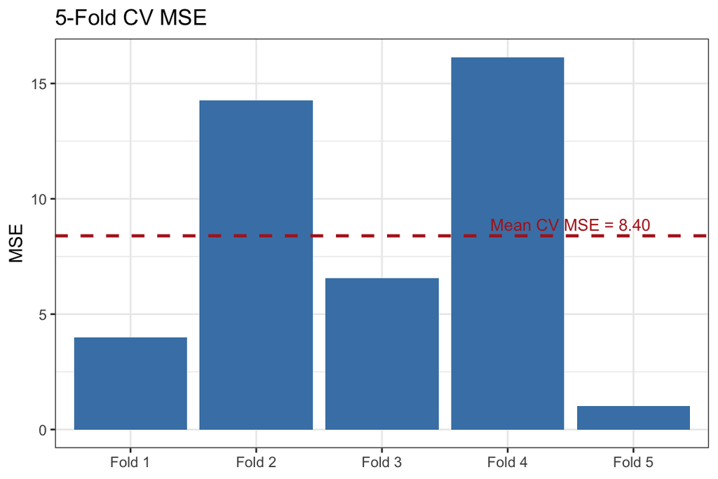

Figure 5.1: 5-fold cross-validation MSE for a linear model on mtcars. The dashed line is the mean CV MSE.

```r
set.seed(99)
k <- 5
folds <- sample(rep(1:k, length.out = nrow(mtcars)))
cv_mse <- numeric(k)

for (fold in 1:k) {
  tr_cv   <- mtcars[folds != fold, ]
  te_cv   <- mtcars[folds == fold, ]
  fit_cv  <- lm(mpg ~ wt + hp + cyl, data = tr_cv)
  pred_cv <- predict(fit_cv, newdata = te_cv)
  cv_mse[fold] <- mean((te_cv$mpg - pred_cv)^2)
}

df_cv <- data.frame(fold = paste0("Fold ", 1:k), mse = cv_mse)

ggplot(df_cv, aes(x = fold, y = mse)) +
  geom_col(fill = "steelblue") +
  geom_hline(yintercept = mean(cv_mse), colour = "firebrick",
             linetype = "dashed", linewidth = 0.9) +
  annotate("text", x = 4.5, y = mean(cv_mse) + 0.5,
           label = sprintf("Mean CV MSE = %.2f", mean(cv_mse)),
           colour = "firebrick", size = 3.5) +
  labs(title = "5-Fold CV MSE", x = NULL, y = "MSE") +
  theme_bw()
```

# 6 Summary

| Concept | Key idea |
| --- | --- |
| Machine learning (Section 1) | Parameters learned from data, not hand-coded |
| Inference vs. prediction (Section 2) | Understand $X \to Y$ vs. accurately predict $\hat{Y}$ |
| Supervised learning (Section 3.1) | Labelled data: estimate $Y = f(X) + \varepsilon$ |
| Unsupervised learning (Section 3.2) | No labels: find structure in $X$ |
| Bias–variance trade-off (Section 4) | Complexity ↑ → bias ↓, variance ↑ |
| Evaluation (Section 5) | MSE/RMSE/R² (regression); accuracy/F₁ (classification) |

# 7 References

- James, G., Witten, D., Hastie, T., & Tibshirani, R. (2023). *An Introduction to Statistical Learning with Applications in R* (2nd ed.). Springer. Chapters 1–2.